# NIRS_rev1

Slaven Pikija

2026-09-24

## Methods

### Analysis of temporal rSO₂ changes around reperfusion

### NIRS data preprocessing

Continuous bilateral rSO₂ measurements were recorded at approximately 6-second intervals. Raw measurements from the left and right frontal sensors were retained separately and ordered according to their original acquisition timestamps. Date and clock time were combined into a single timestamp, and elapsed time was calculated relative to the first available measurement for each patient and hemisphere.

Raw values were retained unchanged for quality-control purposes. Values coded as zero in the source data were treated as invalid measurements and converted to missing values before signal processing. Missing values occurring within short internal signal gaps were reconstructed by linear interpolation using the actual measurement timestamps. Interpolation was restricted to gaps bracketed by valid measurements no more than 30 seconds apart; longer gaps and missing values at the beginning or end of a recording were not interpolated.

Within-patient pre- and post-reperfusion rSO₂ values were compared separately (4% cut-off values Anuss et al.) for the affected and unaffected hemispheres using paired Wilcoxon signed-rank tests. Individual paired measurements were displayed graphically to assess the consistency and heterogeneity of patient-level responses.

To directly compare temporal changes between hemispheres, a patient-level change score was calculated for each hemisphere as ΔrSO₂ = post-reperfusion rSO₂ − pre-reperfusion rSO₂. The affected- and unaffected-hemisphere change scores were subsequently compared within patients using a paired Wilcoxon signed-rank test. Results are reported as medians with interquartile ranges (IQRs). The Hodges–Lehmann estimate of the paired between-hemisphere difference in change is reported with its 95% confidence interval. All differences in rSO₂ are expressed in percentage points.

Multivariable logistic regression analyses were performed to explore whether NIRS-derived rSO₂ measures were independently associated with favorable functional outcome at 3 months, defined as mRS 0–2 versus 3–6. Favorable outcome (mRS 0–2) was coded as the event of interest. In the primary baseline model, NIRS measurements were parameterized as the overall hemispheric rSO₂ level, calculated from the two hemisphere-specific median rSO₂ values, and the absolute interhemispheric rSO₂ difference, representing the magnitude of hemispheric asymmetry irrespective of direction. The model was adjusted for age, admission NIHSS, and successful angiographic reperfusion (mTICI 2b–3). Age, NIHSS, and NIRS-derived measures were entered as continuous variables.

In a sensitivity analysis, the absolute interhemispheric difference was replaced by the categorical direction of baseline asymmetry (affected hemisphere higher, no relevant asymmetry, or unaffected hemisphere higher), using affected hemisphere higher as the reference category.

A separate exploratory model was performed in patients with successful reperfusion (mTICI 2b–3) and available paired NIRS measurements. The differential temporal rSO₂ response between hemispheres was calculated for each patient as [(post-reperfusion − pre-reperfusion)affected − (post-reperfusion − pre-reperfusion)unaffected]. Positive values therefore indicated a relative upward shift in rSO₂ in the affected hemisphere compared with the unaffected hemisphere. Reperfusion status was not included in this model because the analysis was restricted to patients with mTICI 2b–3. Results are reported as odds ratios (ORs) with 95% confidence intervals (CIs).

## Results

Among 177 patients, the hemisphere with lower rSO₂ correctly corresponded to the angiographically affected hemisphere in 69 patients (39.0%; 95% CI 31.8–46.6%).

Classification was incorrect in 45 patients (25.4%; 95% CI 19.2–32.5%),

while 63 patients (35.6%; 95% CI 28.6–43.1%) were classified as indeterminate because no relevant interhemispheric asymmetry was present.

Among the 114 patients with a directional interhemispheric difference, the lower-rSO₂ hemisphere correctly corresponded to the angiographically affected hemisphere in 69 patients (60.5%; 95% CI 50.9–69.6%; exact binomial p = 0.031).

Among patients with meaningful recanalisation and complete paired measurements, median rSO₂ in the affected hemisphere changed from 69.5% (IQR 64.4–79.0%) at the start of recording to 72.0% (IQR 67.0–78.2%) in the post-intervention period.

The Hodges–Lehmann estimate of the paired shift was 1.5 percentage points (95% CI 0.5 to 2.5; Wilcoxon signed-rank p = 0.005).

In the unaffected hemisphere, median rSO₂ changed from 73.0% (IQR 65.8–78.2%) to 73.0% (IQR 67.8–78.0%).

The Hodges–Lehmann estimate of the paired shift was 0.5 percentage points (95% CI -0.5 to 1.5; Wilcoxon signed-rank p = 0.287) (Figure xxx_2).

To directly compare the temporal response between hemispheres, patient-level post–pre changes in rSO₂ were calculated for each hemisphere. The median change was 1.0 percentage points (IQR -2.0–5.0) in the affected hemisphere and 0.0 percentage points (IQR -3.0–4.0) in the unaffected hemisphere.

The Hodges–Lehmann estimate of the paired between-hemisphere difference in change was 1.0 percentage points (95% CI 0.0 to 1.5; paired Wilcoxon signed-rank p = 0.023). The patient-level comparison of temporal changes between hemispheres is shown in Figure xxx_3.

### NIRS effect according to collateral and reperfusion status

At the start of the procedure, the median affected–unaffected rSO₂ difference was -2.0 percentage points (IQR -8.2 to 3.0) in patients with poor collaterals (n = 68) and -0.8 percentage points (IQR -4.2 to 3.0) in patients with good collaterals (n = 48).

The Hodges–Lehmann estimate of the between-group difference was -2.0 percentage points (95% CI -4.5 to 1.0; Wilcoxon rank-sum p = 0.161).

Supplemental Table X. Multivariable logistic regression models evaluating associations of baseline NIRS-derived rSO₂ measures and peri-procedural changes in rSO₂ with 3-month functional outcome (mRS 0–2 vs 3–6).

|  | Variable | Odds ratio (95% CI) | p value |
| --- | --- | --- | --- |
| Baseline overall oxygenation and abs interhemispheric difference | Intercept | 390.80 (3.73–57470.04) | 0.015 |
|  | Overall rSO₂, per 1%-point | 1.00 (0.96–1.05) | 0.916 |
|  | Absolute interhemispheric rSO₂ difference, per 1%-point | 0.92 (0.84–1.00) | 0.062 |
|  | Age, per year | 0.93 (0.90–0.96) | <0.001 |
|  | Admission NIHSS, per point | 0.82 (0.75–0.89) | <0.001 |
|  | Successful reperfusion (TICI 2b–3) | 6.36 (1.61–33.54) | 0.015 |
| Baseline interhemispheric difference direction | Intercept | 367.55 (3.48–53025.43) | 0.016 |
|  | Overall rSO₂, per 1%-point | 1.00 (0.95–1.04) | 0.880 |
|  | ratio_signifno | 1.39 (0.54–3.62) | 0.493 |
|  | Unaffected hemisphere higher | 0.79 (0.30–2.07) | 0.623 |
|  | Age, per year | 0.93 (0.90–0.96) | <0.001 |
|  | Admission NIHSS, per point | 0.83 (0.75–0.90) | <0.001 |
|  | Successful reperfusion (TICI 2b–3) | 6.41 (1.68–32.99) | 0.012 |
| Intrahemispheric difference in recanalised population (start-post) | Intercept | 3067.92 (29.18–551164.75) | 0.001 |
|  | Age, per year | 0.93 (0.90–0.96) | <0.001 |
|  | Admission NIHSS, per point | 0.82 (0.74–0.89) | <0.001 |
|  | Overall rSO₂, per 1%-point | 1.00 (0.95–1.04) | 0.862 |
|  | Change in interhemispheric rSO₂ difference, per 1%-point | 1.06 (0.99–1.14) | 0.113 |

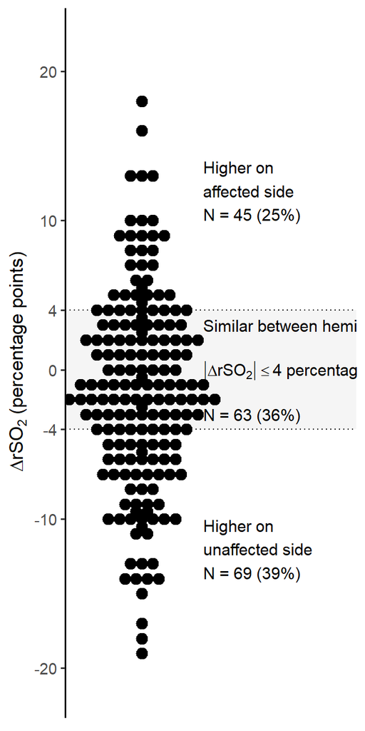

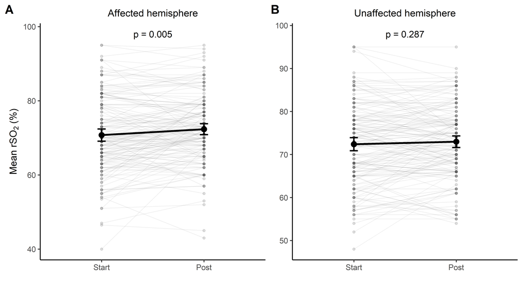

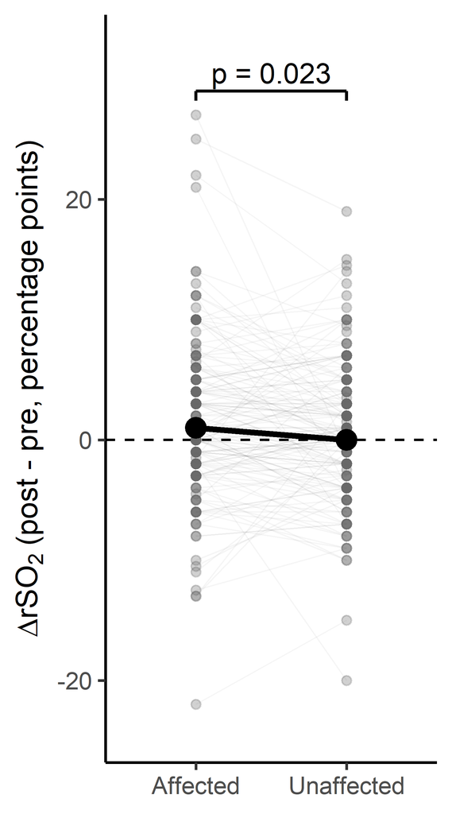

Supplemental Figure xxx_3. Comparison of post–pre changes in rSO₂ between hemispheres. For each patient, the change in median rSO₂ was calculated as post-reperfusion minus pre-reperfusion rSO₂ separately for the affected and unaffected hemispheres. Individual patient-level changes are shown for both hemispheres; paired observations originate from the same patient. The dashed horizontal line denotes no temporal change. Only patients with meaningful angiographic recanalisation and complete measurements in both hemispheres were included (N = 157). The p value represents the paired Wilcoxon signed-rank comparison of post–pre changes between the affected and unaffected hemispheres.